# PA1_template.Rmd

-Pareen Jain

17 July 2015

### Loading and preprocessing the data

- Load the data The original data set:

```r
library(knitr)
if(!file.exists("PA1")){ dir.create("PA1")}
setwd("E:/CourseraDataScience/Workspace/PA1")
fileurl <- "https://d396qusza40orc.cloudfront.net/repdata%2Fdata%2Factivity.zip"
download.file(fileurl, destfile = "E:/CourseraDataScience/Workspace/PA1/activity.zip", method = "curl")
activity <- read.csv(unz("activity.zip", "activity.csv"), header=TRUE)
str(activity)
```

```
## 'data.frame':    17568 obs. of  3 variables:
##  $ steps   : int  NA NA NA NA NA NA NA NA NA NA ...
##  $ date    : Factor w/ 61 levels "2012-10-01","2012-10-02",..: 1 1 1 1 1 1 1 1 1 1 ...
##  $ interval: int  0 5 10 15 20 25 30 35 40 45 ...
```

- Process/transform the data into a suitable format. We change the class of the date variable from factor into ‘Date’. The processed data set:

```r
activity$date <- as.Date(as.character(activity$date))
str(activity)
```

```
## 'data.frame':    17568 obs. of  3 variables:
##  $ steps   : int  NA NA NA NA NA NA NA NA NA NA ...
##  $ date    : Date, format: "2012-10-01" "2012-10-01" ...
##  $ interval: int  0 5 10 15 20 25 30 35 40 45 ...
```

### What is mean total number of steps taken per day?

-Calculate the total number of steps taken per day

```r
steps_day <- tapply(activity$steps, activity$date, sum)
```

-Make a histogram of the total number of steps taken each day

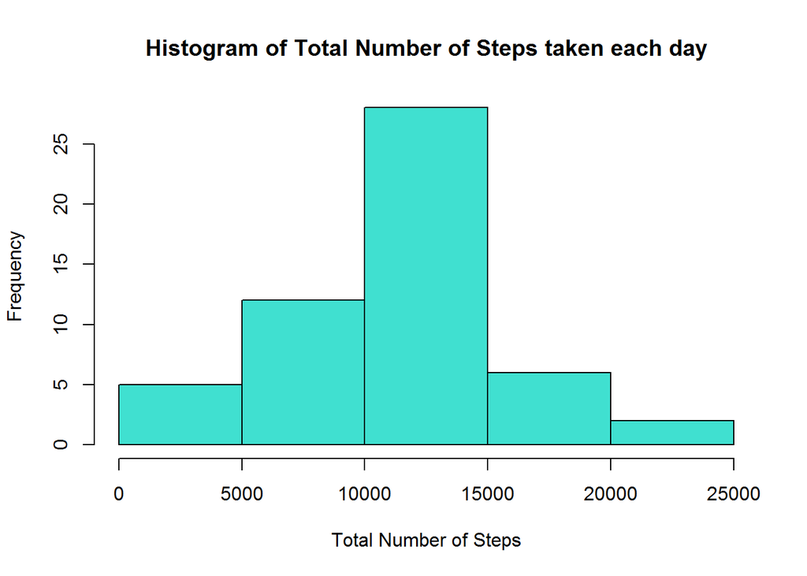

```r
hist(steps_day, main = "Histogram of Total Number of Steps taken each day", xlab = "Total Number of Steps", col = "turquoise")
```

```r
Mean <- mean(steps_day, na.rm = TRUE)
Median <- median(steps_day, na.rm = TRUE)
```

### What is the average daily activity pattern?

-Make a time series plot of the 5-minute interval (x-axis) and the average number of steps taken, averaged across all days (y-axis)

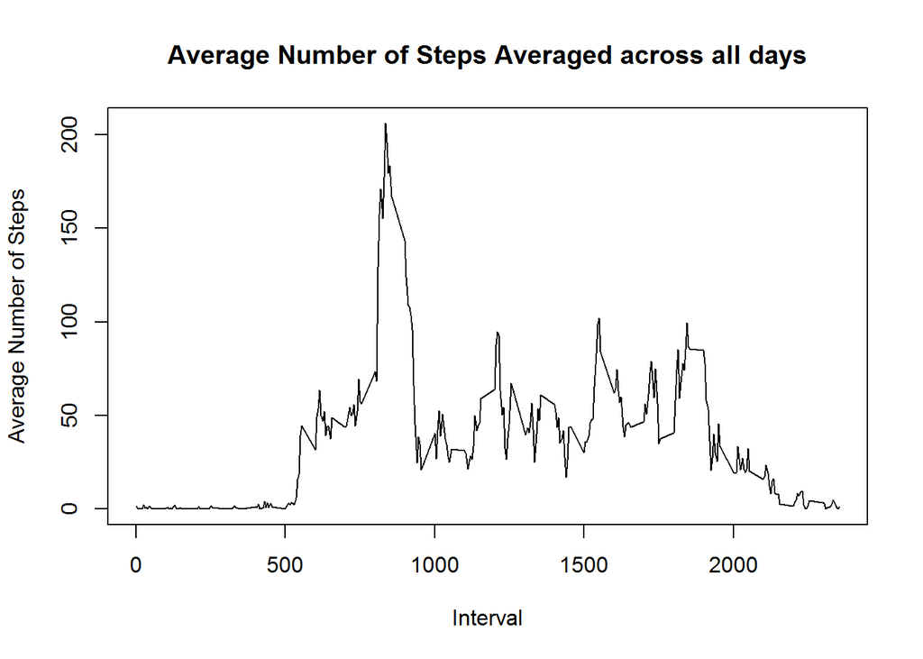

```r
steps_interval <- aggregate(steps ~ interval, activity, mean)
plot(steps_interval$interval, steps_interval$steps, type = "l", lwd = 1, main = "Average Number of Steps Averaged across all days", xlab = "Interval", ylab = "Average Number of Steps")
```

-Which 5-minute interval, on average across all the days in the dataset, contains the maximum number of steps?

```r
max_steps <- steps_interval[which.max(steps_interval$steps), ]["interval"]
```

The interval with the maximum number of steps is the 835th interval.

### Imputing missing values

-Calculate and report the total number of missing values in the dataset

```r
NAs <- sum(!complete.cases(activity))
```

There are 2304 rows with missing values in the data set.

-Filling in all of the missing values in the dataset using the mean for that 5-minute interval and Creating a new Dataset.

```r
activity_new <- activity
for(i in 1:nrow(activity_new)) {
  if(is.na(activity_new$steps[i])) {
    activity_new$steps[i] <- steps_interval$steps[which(steps_interval$interval == activity_new$interval[i])]
  }
}
```

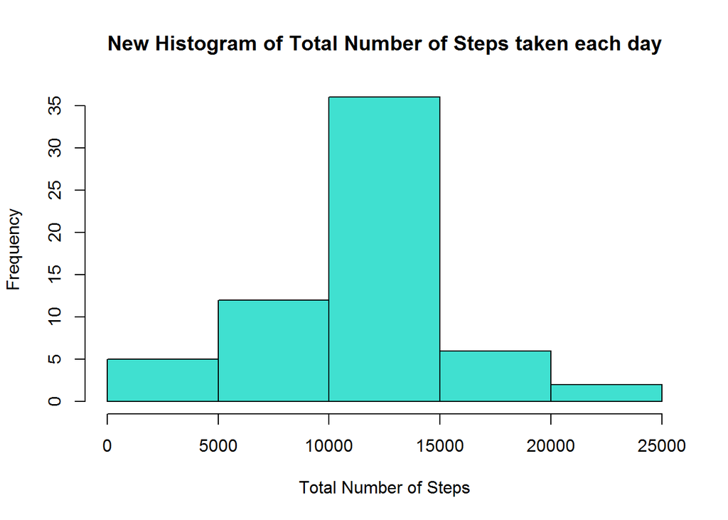

```r
steps_day_new <- tapply(activity_new$steps, activity_new$date, sum)
hist(steps_day_new, main = "New Histogram of Total Number of Steps taken each day", xlab = "Total Number of Steps", col = "turquoise")
```

```r
Mean_new <- mean(steps_day_new, na.rm = TRUE)
Median_new <- median(steps_day_new, na.rm = TRUE)
```

### Are there differences in activity patterns between weekdays and weekends?

-Create a new factor variable in the dataset with two levels - “weekday” and “weekend” indicating whether a given date is a weekday or weekend day.

```r
activity_new$day <- weekdays(activity_new$date)
activity_new$daytype <- c()
for(i in 1:nrow(activity_new)) {
  if(activity_new$day[i] == "Saturday" | activity_new$day[i] == "Sunday") {
    activity_new$daytype[i] <- "weekend"
  }
  else{
    activity_new$daytype[i] <- "weekday"
  }
}
activity_new$daytype <- as.factor(activity_new$daytype)
```

-Make a panel plot containing a time series plot of the 5-minute interval (x-axis) and the average number of steps taken, averaged across all weekday days or weekend days (y-axis).

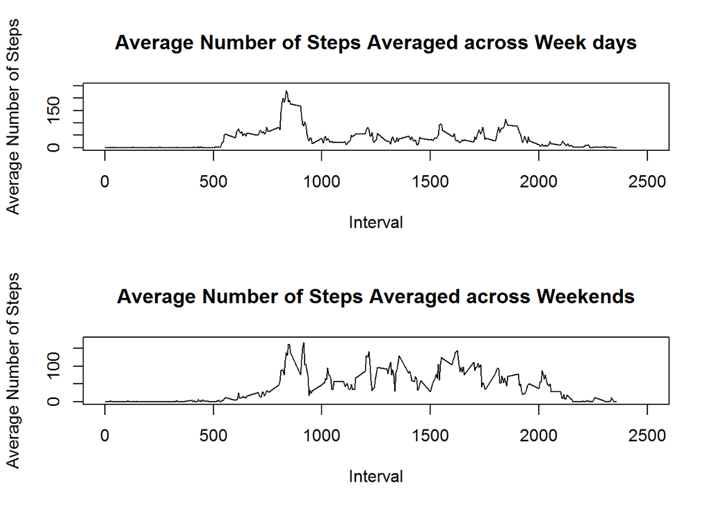

```r
par(mfrow = c(2, 1))
steps_interval_new <- aggregate(steps ~ interval + daytype, data = activity_new, mean)
weekend_set <- subset(steps_interval_new, daytype == "weekend")
weekday_set <- subset(steps_interval_new, daytype == "weekday")
plot(weekday_set$interval, weekday_set$steps, type = "l", lwd = 1, main = "Average Number of Steps Averaged across Week days", xlab = "Interval", ylab = "Average Number of Steps", xlim = c(0, 2500), ylim = c(0, 250))
plot(weekend_set$interval, weekend_set$steps, type = "l", lwd = 1, main = "Average Number of Steps Averaged across Weekends", xlab = "Interval", ylab = "Average Number of Steps", xlim = c(0, 2500), ylim = c(0, 175))
```